# Allocating Grant Money using College ScoreCard Data

December 5, 2016

## Introduction

- In this report we assess the performance of publicly funded schools to determine the allocation of grant money for policymakers.
- Specifically, we attempt to identify the best schools in the US in terms of their demographic, academic, and socioeconomic characteristics in order to help increase equity and graduation rates for underserved populations.

## More Background

- A main concern for policymakers and families alike is the quality of higher education institutions.
- Demand in the labor market for workers with educational attainment beyond high school growing significantly

=growing inequality for underserved populations

- In an effort to promote equity and level the playing field, the government has set up several programs, such as the Pell Grant, that help enable underserved populations to attend university.

## Data

- To perform our analyses, we use data from College Scorecard, provided by the US Department of Education.
- The full College Scorecard dataset contains extensive data on characteristics and indicators for all federal financial aid eligible schools in the US every year for the past several years.
- For the purpose of our study, we select several variables that we deemed relevant to determining performance of a school. These are: **total number of students**, **race**, **four year completion rate**, **cost of attendance**, **first generation status**, **income**, and **aggregate earnings**.

## Exploratory Data Analysis -Cost

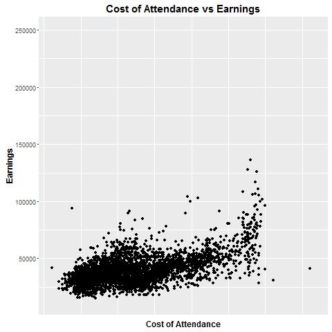

## Exploratory Data Analysis -Cost

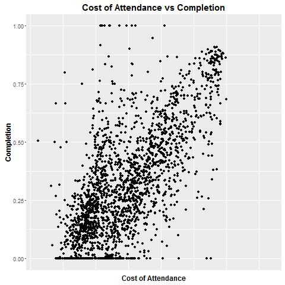

## Exploratory Data Analysis -First Gen

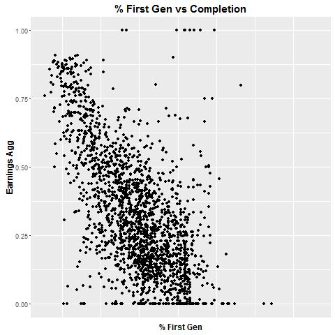

## Exploratory Data Analysis -First Gen

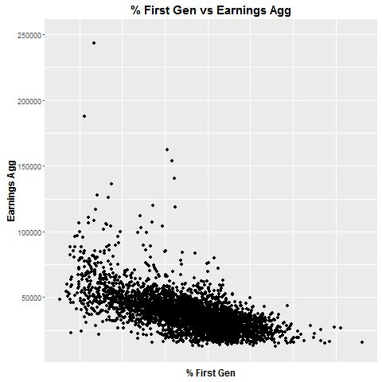

## Exploratory Data Analysis -SAT

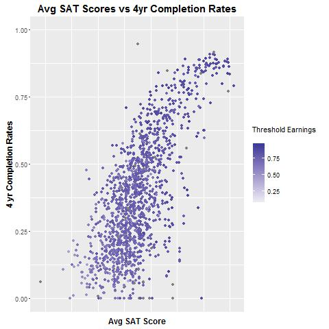

## Exploratory Data Analysis -SAT

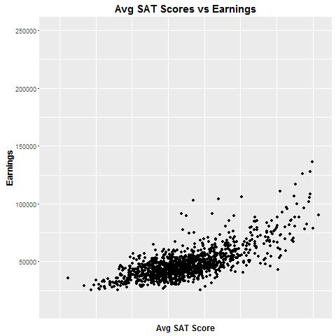

## Exploratory Data Analysis -Race

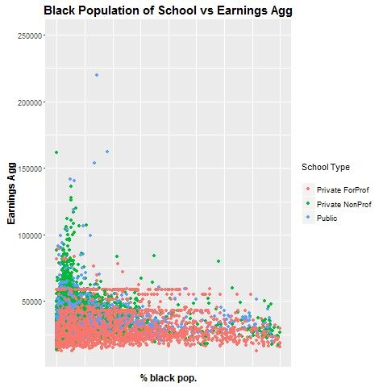

## Exploratory Data Analysis -Race

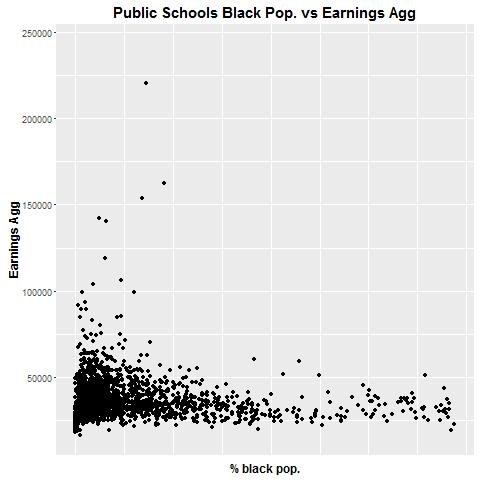

## Exploratory Data Analysis

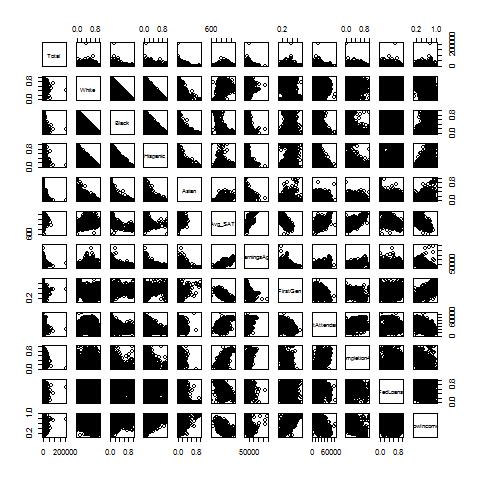

## Most Urgent Schools

- Using these results, we compiled 3 lists of the 25 schools with the most low income students, the students with the most federal loans and then the most first generation students.
- There were 7 schools falling in 2 of these categories including **Lansing Community College, Mississippi Valley State University, Upper Cape Cod Regional Technical School, The Artisan College of Cosmetology, American College for Medical Careers, West Coast University-Dallas, Keiser University-Port St Lucie**.
- This is a good starting point for which schools to allocate money to.